# |IS 605 FUNDAMENTALS OF COMPUTATIONAL MATHEMATICS - WEEK 11 | Data Analysis

Author:MUSA T GANIYU

> Question 1: Using R’s lm function, perform regression analysis and measure the significance of the independent variables for the following two data sets. In the first case, you are evaluating the statement that we hear that Maximum Heart Rate of a person is related to their age by the following equation:
- MaxHR = 220 - Age

```r
options(warn = -1)
suppressMessages(library(ggplot2))
suppressMessages(library(plotly))
library(knitr)

dataset <- data.frame( age = c(18, 23, 25, 35, 65, 54, 34, 56, 72, 19, 23, 42, 18, 39, 37), maxHR = c(202, 186, 187, 180, 156, 169, 174, 172, 153, 199, 193, 174, 198, 183, 178))
str(dataset)
```

```
## 'data.frame':    15 obs. of  2 variables:
##  $ age  : num  18 23 25 35 65 54 34 56 72 19 ...
##  $ maxHR: num  202 186 187 180 156 169 174 172 153 199 ...
```

SETTING UP HYPOTHESIS:

- Null Hypothesis: The population parameters(means) are the same

${ H }_{ 0 }\quad :\quad { \mu }_{ 1 }=\quad { \mu }_{ 2 }\quad ={ \quad \mu }_{ 3 }............={ \mu }_{ n }$

- Alternative Hypothesis: Not ${ H }_{ 0 }\quad$

${ H }_{ 1 }\quad :\quad { \mu }_{ 1 }\not=\quad { \mu }_{ 2 }\quad\not ={ \quad \mu }_{ 3 }............\not={ \mu }_{ n }$

> Rejection:

Rejection ${ H }_{ 0 }$ if the calculated value (P-Value) is less the tabulated value(Table Value = 0.05) i.e P $\le \quad \alpha$, at 0.05, otherwise do not reject ${ H }_{ 0 }\quad$.

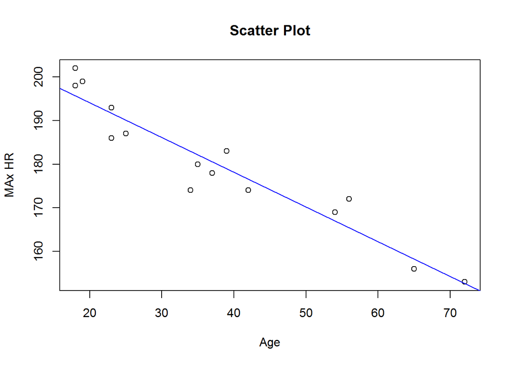

```r
plot(dataset$age, dataset$maxHR, main = "Scatter Plot", xlab = "Age", ylab = "MAx HR")
abline(lm(dataset$maxHR~dataset$age), col="blue")
```

Above is the plot of Age against maxHR, and it reveals that there is a strong negative correlation between Age and MaxHR. Where its correlation co-efficient is stated below;

```r
cor(dataset$maxHR, dataset$age)
```

```
## [1] -0.9534656
```

Below is the linear model between Age and MaxHR with the plot of Residual against the fitted values.

```r
linearmodel <- lm(dataset$maxHR~dataset$age)

summary(linearmodel)
```

```
##
## Call:
## lm(formula = dataset$maxHR ~ dataset$age)
##
## Residuals:
##     Min      1Q  Median      3Q     Max
## -8.9258 -2.5383  0.3879  3.1867  6.6242
##
## Coefficients:
##              Estimate Std. Error t value Pr(>|t|)
## (Intercept) 210.04846    2.86694   73.27  < 2e-16 ***
## dataset$age  -0.79773    0.06996  -11.40 3.85e-08 ***
## ---
## Signif. codes:  0 '***' 0.001 '**' 0.01 '*' 0.05 '.' 0.1 ' ' 1
##
## Residual standard error: 4.578 on 13 degrees of freedom
## Multiple R-squared:  0.9091, Adjusted R-squared:  0.9021
## F-statistic:   130 on 1 and 13 DF,  p-value: 3.848e-08
```

selecting best model using both Forward and backward selection

```r
stepwise <- step(linearmodel, direction = "both")
```

```
## Start:  AIC=47.49
## dataset$maxHR ~ dataset$age
##
##               Df Sum of Sq     RSS    AIC
## <none>                      272.43 47.490
## - dataset$age  1    2724.5 2996.93 81.459
```

```r
summary(stepwise)
```

```
##
## Call:
## lm(formula = dataset$maxHR ~ dataset$age)
##
## Residuals:
##     Min      1Q  Median      3Q     Max
## -8.9258 -2.5383  0.3879  3.1867  6.6242
##
## Coefficients:
##              Estimate Std. Error t value Pr(>|t|)
## (Intercept) 210.04846    2.86694   73.27  < 2e-16 ***
## dataset$age  -0.79773    0.06996  -11.40 3.85e-08 ***
## ---
## Signif. codes:  0 '***' 0.001 '**' 0.01 '*' 0.05 '.' 0.1 ' ' 1
##
## Residual standard error: 4.578 on 13 degrees of freedom
## Multiple R-squared:  0.9091, Adjusted R-squared:  0.9021
## F-statistic:   130 on 1 and 13 DF,  p-value: 3.848e-08
```

```r
kable(confint(stepwise))
```

|  | 2.5 % | 97.5 % |
| --- | --- | --- |
| (Intercept) | 203.854813 | 216.2421034 |
| dataset$age | -0.948872 | -0.6465811 |

Plot of fitted values and showing relationship between Age and MaxHR

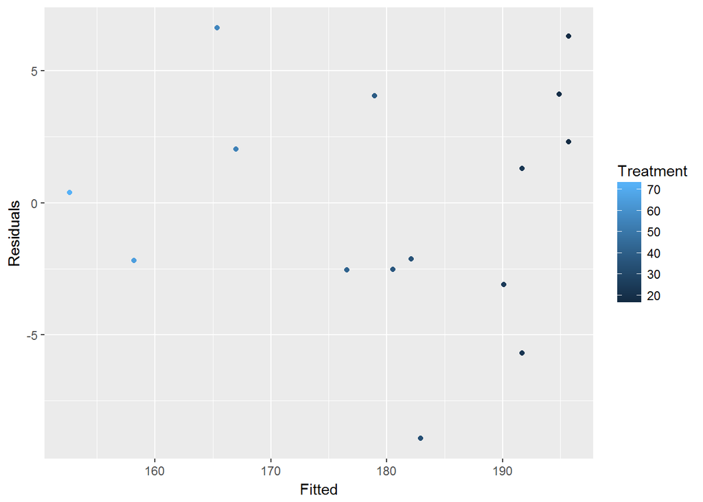

```r
residual_age = data.frame(Fitted = fitted(stepwise),
Residuals = resid(stepwise), Treatment = dataset$age)

ggplot(residual_age, aes(Fitted, Residuals, colour = Treatment)) + geom_point()
```

> Question 2:

Using the Auto data set from Assignment 5 (also attached here) perform a Linear Re- gression analysis using mpg as the dependent variable and the other 4 (displacement, horse- power, weight, acceleration) as independent variables. What is the final linear regression fit equation? Which of the 4 independent variables have a significant impact on mpg? What are their corresponding significance levels? What are the standard errors on each of the coeficients? Please perform this experiment in two ways. First take any random 40 data points from the entire auto data sample and perform the linear regression fit and measure the 95% confidence intervals. Then, take the entire data set (all 392 points) and perform linear regression and measure the 95% confidence intervals. Please report the resulting fit equation, their significance values and confidence intervals for each of the two runs. Please submit an R-markdown file documenting your experiments. Your submission should include the final linear fits, and their corresponding signifcance levels. In addition, you should clearly state what you concluded from looking at the fit and their significance levels. 1

```r
auto <- read.csv("C:\\Users\\mascot\\Desktop\\assign11\\assign11\\auto-mpg.txt", header=FALSE, sep = "")

colnames(auto)[1] <- "mpg"
colnames(auto)[2] <- "displacement"
colnames(auto)[3] <- "horsePower"
colnames(auto)[4] <-  "weight"
colnames(auto)[5] <- "acceleration"

kable(head(auto))
```

| mpg | displacement | horsePower | weight | acceleration |
| --- | --- | --- | --- | --- |
| 307 | 130 | 3504 | 12.0 | 18 |
| 350 | 165 | 3693 | 11.5 | 15 |
| 318 | 150 | 3436 | 11.0 | 18 |
| 304 | 150 | 3433 | 12.0 | 16 |
| 302 | 140 | 3449 | 10.5 | 17 |
| 429 | 198 | 4341 | 10.0 | 15 |

```r
set.seed(123)
sample1 <- auto[sample(nrow(auto),40 ), ]
dim(sample1)
```

```
## [1] 40  5
```

SETTING UP HYPOTHESIS:

- Null Hypothesis: The population parameters(means) are the same

${ H }_{ 0 }\quad :\quad { \mu }_{ 1 }=\quad { \mu }_{ 2 }\quad ={ \quad \mu }_{ 3 }............={ \mu }_{ n }$

- Alternative Hypothesis: Not ${ H }_{ 0 }\quad$

${ H }_{ 1 }\quad :\quad { \mu }_{ 1 }\not=\quad { \mu }_{ 2 }\quad\not ={ \quad \mu }_{ 3 }............\not={ \mu }_{ n }$

> Rejection:

Rejection ${ H }_{ 0 }$ if the calculated value (P-Value) is less the tabulated value(Table Value = 0.05) i.e P $\le \quad \alpha$, at 0.05, otherwise do not reject ${ H }_{ 0 }\quad$.

```r
auto_40 <- lm(mpg ~ (displacement+weight+acceleration+horsePower), data=sample1 )

summary(auto_40)
```

```
##
## Call:
## lm(formula = mpg ~ (displacement + weight + acceleration + horsePower),
##     data = sample1)
##
## Residuals:
##    Min     1Q Median     3Q    Max
## -93.94 -23.14   0.88  23.91  57.82
##
## Coefficients:
##                Estimate Std. Error t value Pr(>|t|)
## (Intercept)  -181.52257   76.72932  -2.366 0.023662 *
## displacement    1.06465    0.45286   2.351 0.024487 *
## weight          2.10905    3.88812   0.542 0.590956
## acceleration   -0.27169    1.23100  -0.221 0.826604
## horsePower      0.07931    0.01913   4.145 0.000205 ***
## ---
## Signif. codes:  0 '***' 0.001 '**' 0.01 '*' 0.05 '.' 0.1 ' ' 1
##
## Residual standard error: 32.06 on 35 degrees of freedom
## Multiple R-squared:  0.9127, Adjusted R-squared:  0.9028
## F-statistic: 91.51 on 4 and 35 DF,  p-value: < 2.2e-16
```

```r
stepwise2 <- step(auto_40, direction = "backward")
```

```
## Start:  AIC=282.08
## mpg ~ (displacement + weight + acceleration + horsePower)
##
##                Df Sum of Sq   RSS    AIC
## - acceleration  1      50.1 36034 280.13
## - weight        1     302.5 36286 280.41
## <none>                      35984 282.08
## - displacement  1    5682.3 41666 285.94
## - horsePower    1   17665.4 53649 296.05
##
## Step:  AIC=280.13
## mpg ~ displacement + weight + horsePower
##
##                Df Sum of Sq   RSS    AIC
## - weight        1       254 36288 278.41
## <none>                      36034 280.13
## - displacement  1      5885 41918 284.18
## - horsePower    1     32880 68913 304.07
##
## Step:  AIC=278.41
## mpg ~ displacement + horsePower
##
##                Df Sum of Sq   RSS    AIC
## <none>                      36288 278.41
## - displacement  1     10357 46645 286.46
## - horsePower    1     44048 80336 308.20
```

```r
summary(stepwise2)
```

```
##
## Call:
## lm(formula = mpg ~ displacement + horsePower, data = sample1)
##
## Residuals:
##     Min      1Q  Median      3Q     Max
## -95.361 -21.363  -0.479  25.329  57.690
##
## Coefficients:
##                Estimate Std. Error t value Pr(>|t|)
## (Intercept)  -152.03412   19.17001  -7.931 1.69e-09 ***
## displacement    0.86854    0.26727   3.250  0.00246 **
## horsePower      0.08524    0.01272   6.702 7.10e-08 ***
## ---
## Signif. codes:  0 '***' 0.001 '**' 0.01 '*' 0.05 '.' 0.1 ' ' 1
##
## Residual standard error: 31.32 on 37 degrees of freedom
## Multiple R-squared:  0.912,  Adjusted R-squared:  0.9072
## F-statistic: 191.7 on 2 and 37 DF,  p-value: < 2.2e-16
```

From the above linear regression and best model selection (using backward selection method), we can deduce that only “displacement” and “horsePower” would be select as the best model for further analysis.

Thus the equation;

> mpg = -152.03412 + 0.86854*displacement + 0.08524*horsePower + e

where e is the error term.

```r
confint(stepwise2)
```

```
##                      2.5 %       97.5 %
## (Intercept)  -190.87623979 -113.1919979
## displacement    0.32699838    1.4100863
## horsePower      0.05946911    0.1110127
```

```r
#Note that the confidence intervals below are non-zero.
```

Below is the linear regression model for all the 392 observations and selection of the best model using backward selection method.

```r
auto_392 <- lm(mpg~displacement+horsePower+weight+acceleration, data=auto)
summary(auto_392)
```

```
##
## Call:
## lm(formula = mpg ~ displacement + horsePower + weight + acceleration,
##     data = auto)
##
## Residuals:
##      Min       1Q   Median       3Q      Max
## -104.415  -17.732   -0.143   19.008  152.769
##
## Coefficients:
##                Estimate Std. Error t value Pr(>|t|)
## (Intercept)  -55.479636  25.311954  -2.192 0.028987 *
## displacement   0.631560   0.122416   5.159 3.97e-07 ***
## horsePower     0.082813   0.004906  16.880  < 2e-16 ***
## weight        -3.513924   0.933742  -3.763 0.000194 ***
## acceleration  -0.343757   0.384339  -0.894 0.371658
## ---
## Signif. codes:  0 '***' 0.001 '**' 0.01 '*' 0.05 '.' 0.1 ' ' 1
##
## Residual standard error: 32.14 on 387 degrees of freedom
## Multiple R-squared:  0.9066, Adjusted R-squared:  0.9057
## F-statistic: 939.3 on 4 and 387 DF,  p-value: < 2.2e-16
```

```r
stepwise3 <- step(auto_392, direction = "backward")
```

```
## Start:  AIC=2725.58
## mpg ~ displacement + horsePower + weight + acceleration
##
##                Df Sum of Sq    RSS    AIC
## - acceleration  1       826 400639 2724.4
## <none>                      399812 2725.6
## - weight        1     14631 414443 2737.7
## - displacement  1     27498 427310 2749.7
## - horsePower    1    294354 694166 2939.8
##
## Step:  AIC=2724.38
## mpg ~ displacement + horsePower + weight
##
##                Df Sum of Sq    RSS    AIC
## <none>                      400639 2724.4
## - weight        1     14625 415264 2736.4
## - displacement  1     29596 430235 2750.3
## - horsePower    1    388605 789243 2988.2
```

```r
summary(stepwise3)
```

```
##
## Call:
## lm(formula = mpg ~ displacement + horsePower + weight, data = auto)
##
## Residuals:
##      Min       1Q   Median       3Q      Max
## -103.843  -17.358   -0.539   18.840  153.836
##
## Coefficients:
##                Estimate Std. Error t value Pr(>|t|)
## (Intercept)  -71.181863  18.229425  -3.905 0.000111 ***
## displacement   0.647887   0.121016   5.354 1.48e-07 ***
## horsePower     0.084803   0.004371  19.400  < 2e-16 ***
## weight        -3.513214   0.933501  -3.763 0.000193 ***
## ---
## Signif. codes:  0 '***' 0.001 '**' 0.01 '*' 0.05 '.' 0.1 ' ' 1
##
## Residual standard error: 32.13 on 388 degrees of freedom
## Multiple R-squared:  0.9064, Adjusted R-squared:  0.9057
## F-statistic:  1253 on 3 and 388 DF,  p-value: < 2.2e-16
```

From the above, it can deduce that the following variables have less P-values;

displacements horsePower weight

and the best formular or model is;

> mpg = -71.1817 + 0.6479xdisplacement + 0.0848x horsePower - 3.5132xweight + e

where e is the error term or residual which is 32.13

```r
kable(confint(stepwise3))
```

|  | 2.5 % | 97.5 % |
| --- | --- | --- |
| (Intercept) | -107.0226786 | -35.3410479 |
| displacement | 0.4099571 | 0.8858163 |
| horsePower | 0.0762089 | 0.0933981 |
| weight | -5.3485662 | -1.6778610 |

```r
# Non-zero confidence intervals.
```

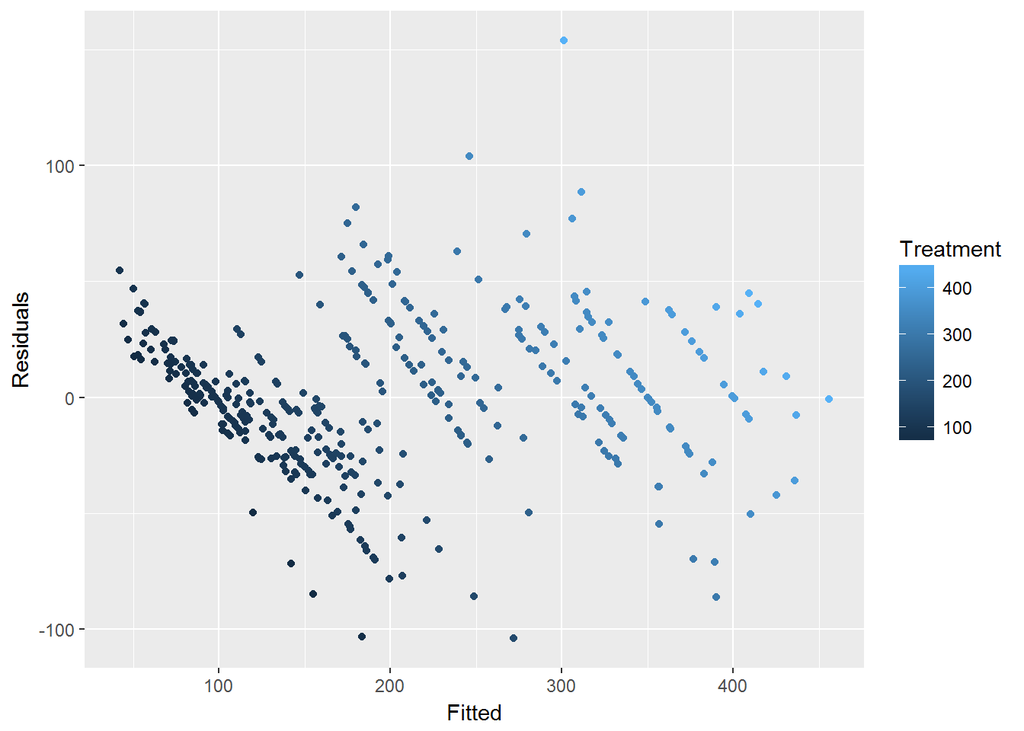

```r
residual_mpg = data.frame(Fitted = fitted(stepwise3),
Residuals = resid(stepwise3), Treatment = auto$mpg)
#fitted with mpg

ggplot(residual_mpg, aes(Fitted, Residuals, colour = Treatment)) + geom_point()
```